# Housing Model

Connor Briggs, Jackson Hamilton, and Olivia Snyder

3/25/2020

```r
library(ggplot2)
```

## 1)Data Summary

- Examine the statistics and values for each variable. Are any missing? Do any values need clarification or modification? If so, why and what did you do?

```r
library(readxl)
housing <- read_excel("Housing.xlsx")
housing
```

```
## # A tibble: 76 x 11
##       id price  size   lot  bath bedrooms yearbuilt agestandardized garagesize
##    <dbl> <dbl> <dbl> <dbl> <dbl>    <dbl>     <dbl>           <dbl>      <dbl>
##  1     1  388   2.18     4   3          4      1940            -3            0
##  2     2  450   2.05     5   3          4      1957            -1.3          2
##  3     3  386   2.11     5   2          4      1955            -1.5          2
##  4     4  350   1.44     6   1          2      1956            -1.4          1
##  5     5  156.  1.8      1   2          4      1994             2.4          1
##  6     6  220   1.96     5   2          3      1940            -3            1
##  7     7  240.  1.8      4   1.1        4      1958            -1.2          1
##  8     8  207   2.25     4   2          4      1961            -0.9          2
##  9     9  270.  1.92     4   2.1        4      1965            -0.5          2
## 10    10  239.  1.92     5   2.1        3      1968            -0.2          2
## # … with 66 more rows, and 2 more variables: status <chr>, elem <chr>
```

After looking over the data, there doesn’t seem to be any missing values. The variables `yearbuilt` and `agestandardized` appear to be similar, so we will check this further below.

```r
housing$sld <- ifelse(housing$status == "sld", 1, 0)
housing$pen <- ifelse(housing$status == "pen", 1, 0)
housing$act <- ifelse(housing$status == "act", 1, 0)
housing$adams <- ifelse(housing$elem == "adams", 1, 0)
housing$crest <- ifelse(housing$elem == "crest", 1, 0)
housing$edge <- ifelse(housing$elem == "edge", 1, 0)
housing$edison <- ifelse(housing$elem == "edison", 1, 0)
housing$harris <- ifelse(housing$elem == "harris", 1, 0)
housing$parker <- ifelse(housing$elem == "parker", 1, 0)
```

Using the ‘ifelse’ statement allows us to look at each level of the two categorical variables. The first categorical variable, `status`, contains three levels. The second categorical variable, `elem`, contains six levels.

```r
summary(housing)
```

```
##        id            price            size            lot
##  Min.   : 1.00   Min.   :155.5   Min.   :1.440   Min.   : 1.000
##  1st Qu.:19.75   1st Qu.:242.8   1st Qu.:1.861   1st Qu.: 3.000
##  Median :38.50   Median :276.0   Median :1.966   Median : 4.000
##  Mean   :38.50   Mean   :285.8   Mean   :1.970   Mean   : 3.987
##  3rd Qu.:57.25   3rd Qu.:336.8   3rd Qu.:2.107   3rd Qu.: 5.000
##  Max.   :76.00   Max.   :450.0   Max.   :2.896   Max.   :11.000
##       bath          bedrooms       yearbuilt    agestandardized
##  Min.   :1.000   Min.   :2.000   Min.   :1905   Min.   :-6.50000
##  1st Qu.:2.000   1st Qu.:3.000   1st Qu.:1958   1st Qu.:-1.22500
##  Median :2.000   Median :3.000   Median :1970   Median :-0.05000
##  Mean   :2.208   Mean   :3.447   Mean   :1969   Mean   :-0.05921
##  3rd Qu.:3.000   3rd Qu.:4.000   3rd Qu.:1980   3rd Qu.: 1.00000
##  Max.   :3.100   Max.   :6.000   Max.   :2005   Max.   : 3.50000
##    garagesize       status              elem                sld
##  Min.   :0.000   Length:76          Length:76          Min.   :0.0
##  1st Qu.:1.000   Class :character   Class :character   1st Qu.:0.0
##  Median :2.000   Mode  :character   Mode  :character   Median :0.5
##  Mean   :1.566                                         Mean   :0.5
##  3rd Qu.:2.000                                         3rd Qu.:1.0
##  Max.   :3.000                                         Max.   :1.0
##       pen              act             adams             crest
##  Min.   :0.0000   Min.   :0.0000   Min.   :0.00000   Min.   :0.00000
##  1st Qu.:0.0000   1st Qu.:0.0000   1st Qu.:0.00000   1st Qu.:0.00000
##  Median :0.0000   Median :0.0000   Median :0.00000   Median :0.00000
##  Mean   :0.1711   Mean   :0.3289   Mean   :0.03947   Mean   :0.07895
##  3rd Qu.:0.0000   3rd Qu.:1.0000   3rd Qu.:0.00000   3rd Qu.:0.00000
##  Max.   :1.0000   Max.   :1.0000   Max.   :1.00000   Max.   :1.00000
##       edge            edison           harris           parker
##  Min.   :0.0000   Min.   :0.0000   Min.   :0.0000   Min.   :0.0000
##  1st Qu.:0.0000   1st Qu.:0.0000   1st Qu.:0.0000   1st Qu.:0.0000
##  Median :0.0000   Median :0.0000   Median :0.0000   Median :0.0000
##  Mean   :0.3421   Mean   :0.1579   Mean   :0.1842   Mean   :0.1974
##  3rd Qu.:1.0000   3rd Qu.:0.0000   3rd Qu.:0.0000   3rd Qu.:0.0000
##  Max.   :1.0000   Max.   :1.0000   Max.   :1.0000   Max.   :1.0000
```

## 2) Exploratory Data Analysis

- Examine some of the variables relationships with price to help you determine which variables might be useful in an initial model. Explain your conclusions from this initial screening.

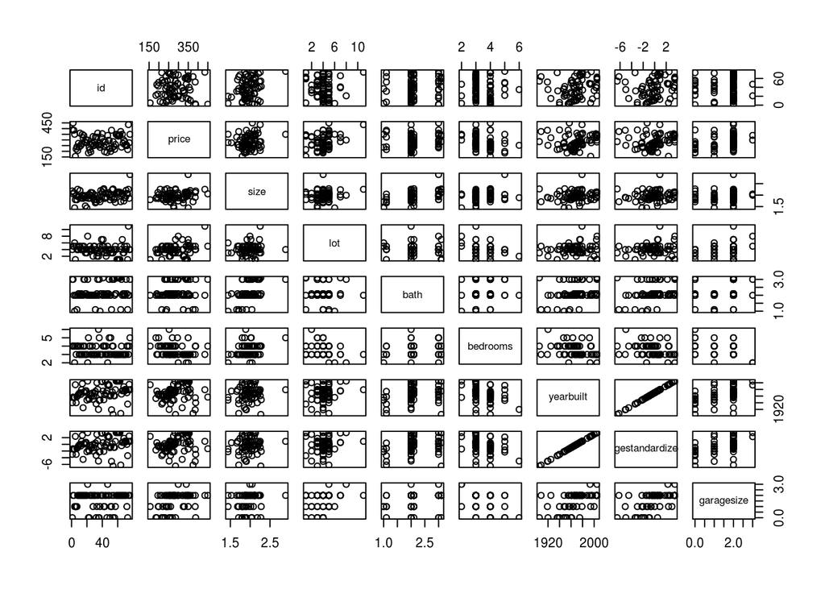

```r
pairs(housing[,1:9])
```

```r
cor(housing[,c(1:9)])
```

```
##                          id       price       size         lot       bath
## id               1.00000000  0.04662108 0.27241069 -0.10244192  0.1547756
## price            0.04662108  1.00000000 0.20143783  0.24423228  0.1746578
## size             0.27241069  0.20143783 1.00000000  0.04079199  0.4725406
## lot             -0.10244192  0.24423228 0.04079199  1.00000000 -0.1709961
## bath             0.15477558  0.17465777 0.47254061 -0.17099609  1.0000000
## bedrooms        -0.04912302 -0.28619746 0.23845303 -0.21382977  0.1468258
## yearbuilt        0.22294217  0.15412476 0.17656934 -0.03933975  0.3345239
## agestandardized  0.22294217  0.15412476 0.17656934 -0.03933975  0.3345239
## garagesize       0.03559640  0.35838608 0.17315776  0.23581664  0.2017635
##                    bedrooms   yearbuilt agestandardized garagesize
## id              -0.04912302  0.22294217      0.22294217  0.0355964
## price           -0.28619746  0.15412476      0.15412476  0.3583861
## size             0.23845303  0.17656934      0.17656934  0.1731578
## lot             -0.21382977 -0.03933975     -0.03933975  0.2358166
## bath             0.14682576  0.33452385      0.33452385  0.2017635
## bedrooms         1.00000000 -0.36315062     -0.36315062 -0.4038039
## yearbuilt       -0.36315062  1.00000000      1.00000000  0.5371846
## agestandardized -0.36315062  1.00000000      1.00000000  0.5371846
## garagesize      -0.40380395  0.53718464      0.53718464  1.0000000
```

## 3) Initial Modeling

ALL VARIABLES

```r
model1 <- lm(price ~ . -id, data = housing)
summary(model1)
```

```
##
## Call:
## lm(formula = price ~ . - id, data = housing)
##
## Residuals:
##    Min     1Q Median     3Q    Max
## -92.82 -33.90  -1.03  25.92 100.18
##
## Coefficients: (10 not defined because of singularities)
##                  Estimate Std. Error t value Pr(>|t|)
## (Intercept)     -131.8469   655.9188  -0.201  0.84135
## size              72.5240    30.9546   2.343  0.02236 *
## lot               10.5661     3.6615   2.886  0.00537 **
## bath               5.4465    11.7427   0.464  0.64440
## bedrooms         -12.0425     9.1063  -1.322  0.19088
## yearbuilt          0.1271     0.3331   0.382  0.70404
## agestandardized        NA         NA      NA       NA
## garagesize         7.6954     9.4677   0.813  0.41944
## statuspen        -19.0612    16.5296  -1.153  0.25327
## statussld        -37.0331    13.9615  -2.653  0.01013 *
## elemcrest          1.2171    34.1327   0.036  0.97167
## elemedge           4.6463    29.0874   0.160  0.87361
## elemedison        84.5640    30.8245   2.743  0.00794 **
## elemharris        50.3950    30.7019   1.641  0.10577
## elemparker       -14.3979    30.0188  -0.480  0.63318
## sld                    NA         NA      NA       NA
## pen                    NA         NA      NA       NA
## act                    NA         NA      NA       NA
## adams                  NA         NA      NA       NA
## crest                  NA         NA      NA       NA
## edge                   NA         NA      NA       NA
## edison                 NA         NA      NA       NA
## harris                 NA         NA      NA       NA
## parker                 NA         NA      NA       NA
## ---
## Signif. codes:  0 '***' 0.001 '**' 0.01 '*' 0.05 '.' 0.1 ' ' 1
##
## Residual standard error: 45 on 62 degrees of freedom
## Multiple R-squared:  0.5401, Adjusted R-squared:  0.4437
## F-statistic: 5.601 on 13 and 62 DF,  p-value: 1.307e-06
```

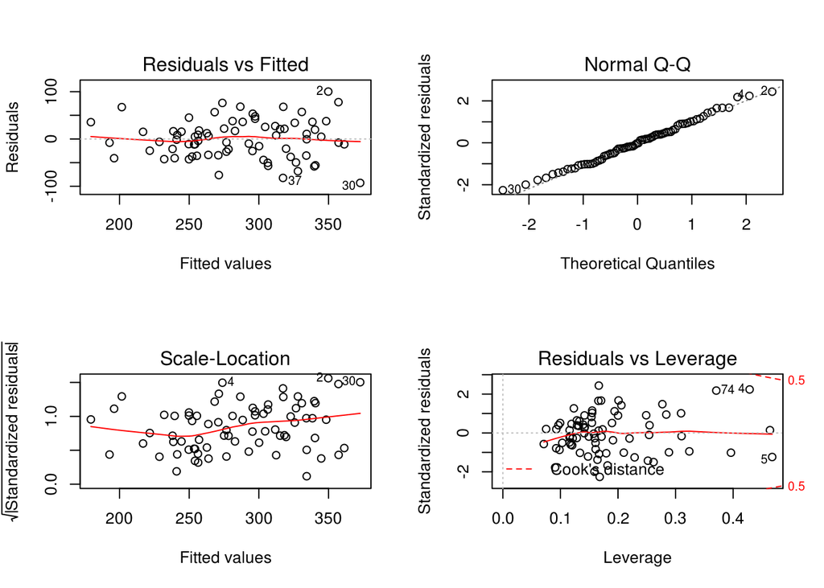

```r
par(mfrow = c(2, 2))
plot(model1)
```

SIGNIFICANT VARIABLES

```r
model2 <- lm(price ~ size + lot + sld + edison + harris, data=housing)
summary(model2)
```

```
##
## Call:
## lm(formula = price ~ size + lot + sld + edison + harris, data = housing)
##
## Residuals:
##     Min      1Q  Median      3Q     Max
## -95.626 -33.643  -2.306  37.115 110.050
##
## Coefficients:
##             Estimate Std. Error t value Pr(>|t|)
## (Intercept)   91.587     50.880   1.800 0.076161 .
## size          71.865     25.070   2.867 0.005477 **
## lot           12.028      3.351   3.589 0.000611 ***
## sld          -38.738     10.898  -3.555 0.000683 ***
## edison        79.351     15.001   5.290 1.33e-06 ***
## harris        62.390     14.506   4.301 5.41e-05 ***
## ---
## Signif. codes:  0 '***' 0.001 '**' 0.01 '*' 0.05 '.' 0.1 ' ' 1
##
## Residual standard error: 45.4 on 70 degrees of freedom
## Multiple R-squared:  0.4715, Adjusted R-squared:  0.4338
## F-statistic: 12.49 on 5 and 70 DF,  p-value: 1.127e-08
```

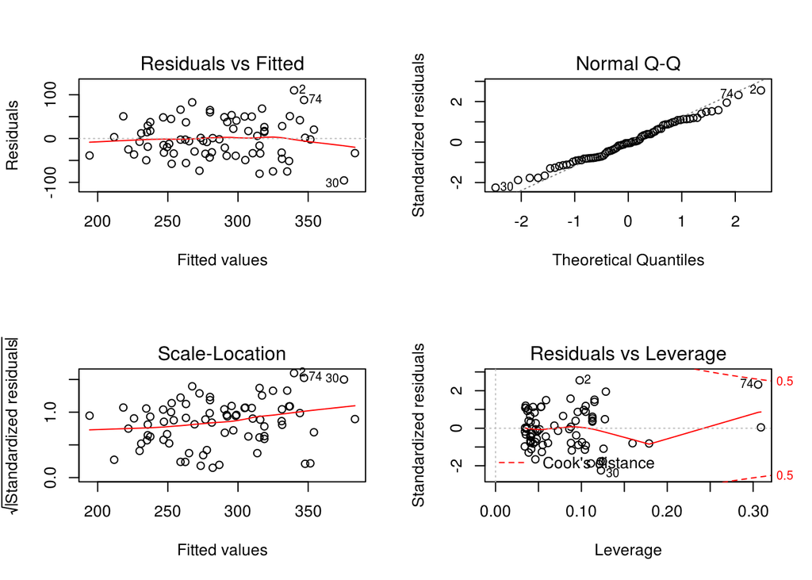

```r
par(mfrow = c(2, 2))
plot(model2)
```

This model has a greater f-statistic, but a decrease in multiple R-squared and adjusted R-squared.

ADDED BEDROOMS

```r
model3 <- lm(price ~ size + bedrooms + lot + sld + edison + harris, data=housing)
summary(model3)
```

```
##
## Call:
## lm(formula = price ~ size + bedrooms + lot + sld + edison + harris,
##     data = housing)
##
## Residuals:
##     Min      1Q  Median      3Q     Max
## -101.09  -31.98   -0.27   28.20  116.16
##
## Coefficients:
##             Estimate Std. Error t value Pr(>|t|)
## (Intercept)  127.556     52.793   2.416 0.018336 *
## size          85.475     25.412   3.364 0.001259 **
## bedrooms     -16.005      7.839  -2.042 0.045021 *
## lot            9.995      3.426   2.918 0.004756 **
## sld          -34.908     10.823  -3.225 0.001925 **
## edison        79.665     14.674   5.429 7.94e-07 ***
## harris        54.393     14.720   3.695 0.000436 ***
## ---
## Signif. codes:  0 '***' 0.001 '**' 0.01 '*' 0.05 '.' 0.1 ' ' 1
##
## Residual standard error: 44.41 on 69 degrees of freedom
## Multiple R-squared:  0.5016, Adjusted R-squared:  0.4583
## F-statistic: 11.57 on 6 and 69 DF,  p-value: 6.344e-09
```

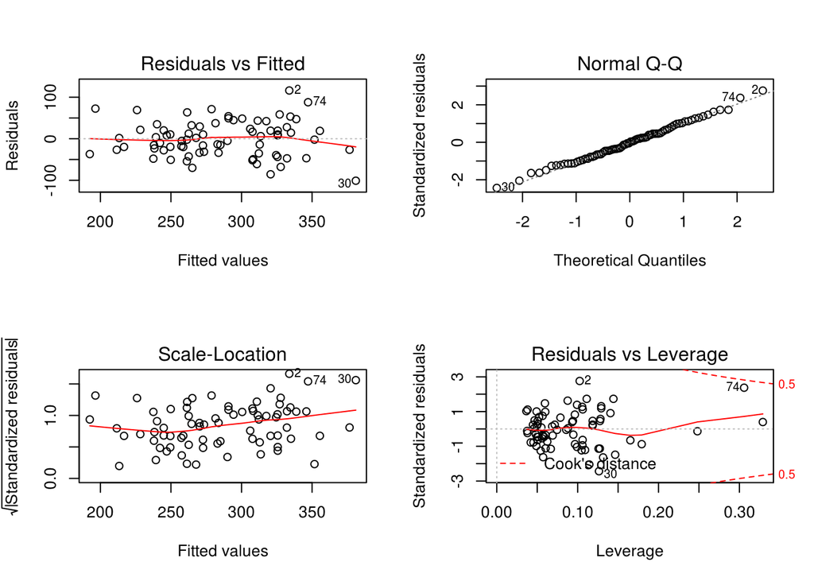

```r
par(mfrow = c(2, 2))
plot(model3)
```

Here, we have added `bedrooms` back in to see what effect that would have on our model. It appears to have improved the adjusted R-squared and the intercept.

ADDED ACT

```r
model4 <- lm(price ~ size + bedrooms + lot + act + sld + edison + harris, data=housing)
summary(model4)
```

```
##
## Call:
## lm(formula = price ~ size + bedrooms + lot + act + sld + edison +
##     harris, data = housing)
##
## Residuals:
##     Min      1Q  Median      3Q     Max
## -92.415 -25.513  -1.347  28.609 114.564
##
## Coefficients:
##             Estimate Std. Error t value Pr(>|t|)
## (Intercept)  112.807     54.470   2.071 0.042157 *
## size          88.078     25.495   3.455 0.000953 ***
## bedrooms     -16.711      7.857  -2.127 0.037064 *
## lot           10.198      3.427   2.976 0.004040 **
## act           16.640     15.410   1.080 0.284045
## sld          -24.043     14.769  -1.628 0.108162
## edison        81.612     14.766   5.527 5.59e-07 ***
## harris        54.566     14.703   3.711 0.000418 ***
## ---
## Signif. codes:  0 '***' 0.001 '**' 0.01 '*' 0.05 '.' 0.1 ' ' 1
##
## Residual standard error: 44.35 on 68 degrees of freedom
## Multiple R-squared:   0.51,  Adjusted R-squared:  0.4596
## F-statistic: 10.11 on 7 and 68 DF,  p-value: 1.338e-08
```

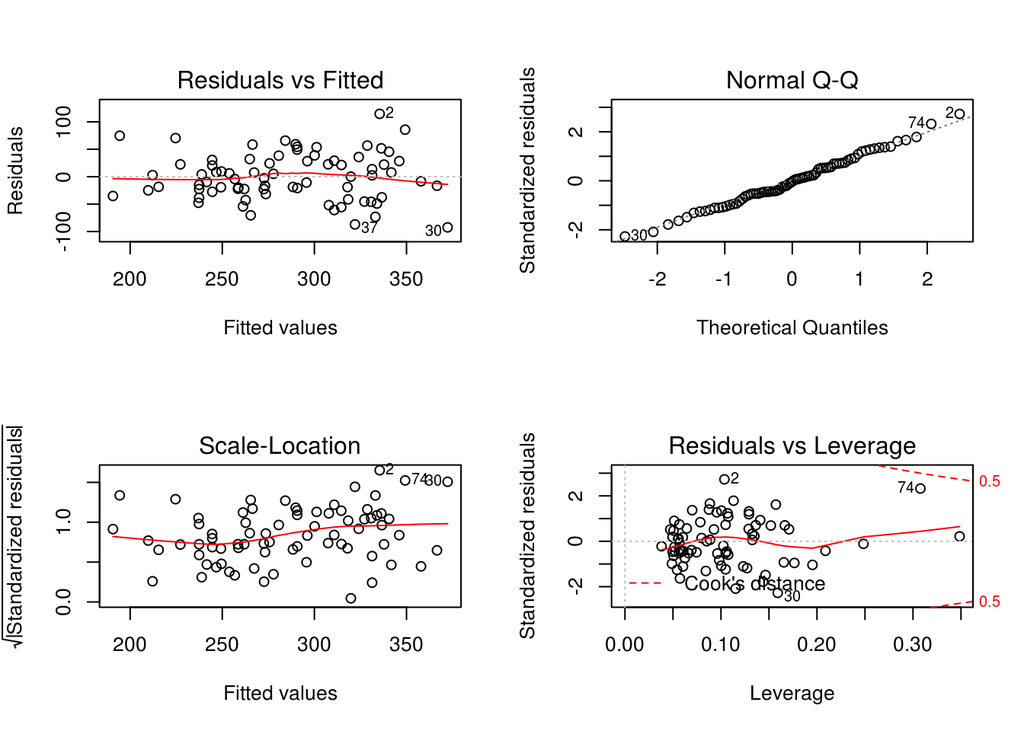

```r
par(mfrow = c(2, 2))
plot(model4)
```

With these model, `act` was added in to see how it would effect `model3`. While the adjusted R-squared goes up slightly, both `act` and `sld` appear to be insignificant.

LOG10 OF ALL VARIABLES

```r
model5 <- lm(price ~ I(log10(size)) + I(log10(lot)) + I(log10(bedrooms))  + sld + edison + harris, data = housing)
summary(model5)
```

```
##
## Call:
## lm(formula = price ~ I(log10(size)) + I(log10(lot)) + I(log10(bedrooms)) +
##     sld + edison + harris, data = housing)
##
## Residuals:
##      Min       1Q   Median       3Q      Max
## -101.118  -28.127   -2.038   22.497  129.161
##
## Coefficients:
##                    Estimate Std. Error t value Pr(>|t|)
## (Intercept)          216.01      47.68   4.530 2.40e-05 ***
## I(log10(size))       425.57     119.35   3.566 0.000664 ***
## I(log10(lot))         52.35      27.11   1.931 0.057576 .
## I(log10(bedrooms))  -166.37      64.94  -2.562 0.012598 *
## sld                  -35.44      11.24  -3.152 0.002402 **
## edison                78.76      15.13   5.204 1.91e-06 ***
## harris                51.81      15.61   3.318 0.001450 **
## ---
## Signif. codes:  0 '***' 0.001 '**' 0.01 '*' 0.05 '.' 0.1 ' ' 1
##
## Residual standard error: 45.78 on 69 degrees of freedom
## Multiple R-squared:  0.4703, Adjusted R-squared:  0.4243
## F-statistic: 10.21 on 6 and 69 DF,  p-value: 4.591e-08
```

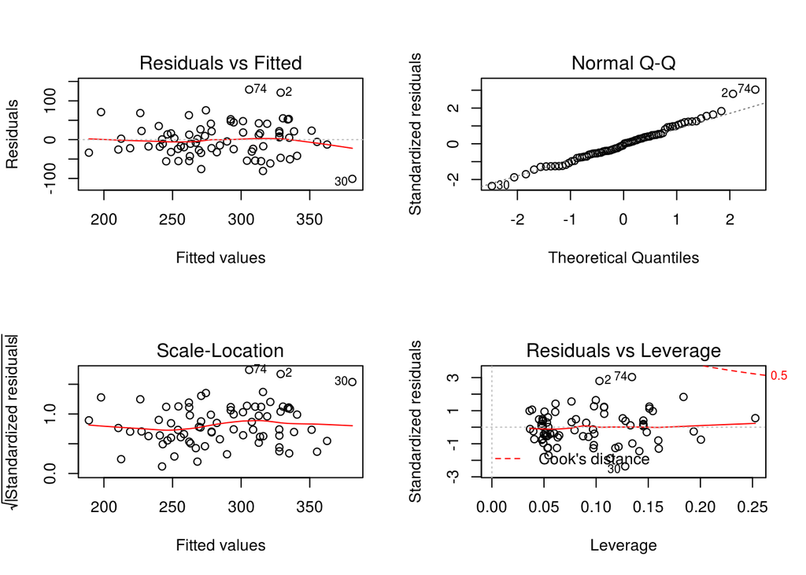

```r
par(mfrow = c(2, 2))
plot(model5)
```

Taking Log10 of each variable in model3, we can see that this decreases the overall strength of this model significantly. Our adjusted R-squared value drops down to $0.4243$, and our f-statistic decreases as well.

SQUARED OF ALL VARIABLES

```r
model6 <- lm(price ~ I((size)^2) + I((lot)^2) + I((bedrooms)^2) + sld + edison + harris, data = housing)
summary(model6)
```

```
##
## Call:
## lm(formula = price ~ I((size)^2) + I((lot)^2) + I((bedrooms)^2) +
##     sld + edison + harris, data = housing)
##
## Residuals:
##    Min     1Q Median     3Q    Max
## -97.75 -29.60  -0.36  30.89 117.23
##
## Coefficients:
##                 Estimate Std. Error t value Pr(>|t|)
## (Intercept)     207.1460    25.2641   8.199 8.64e-12 ***
## I((size)^2)      19.0651     6.0480   3.152 0.002397 **
## I((lot)^2)        1.1690     0.3236   3.612 0.000572 ***
## I((bedrooms)^2)  -1.8165     0.9985  -1.819 0.073209 .
## sld             -35.5792    10.4840  -3.394 0.001146 **
## edison           80.6079    14.3230   5.628 3.63e-07 ***
## harris           52.5060    13.8689   3.786 0.000323 ***
## ---
## Signif. codes:  0 '***' 0.001 '**' 0.01 '*' 0.05 '.' 0.1 ' ' 1
##
## Residual standard error: 43.36 on 69 degrees of freedom
## Multiple R-squared:  0.5249, Adjusted R-squared:  0.4836
## F-statistic: 12.71 on 6 and 69 DF,  p-value: 1.326e-09
```

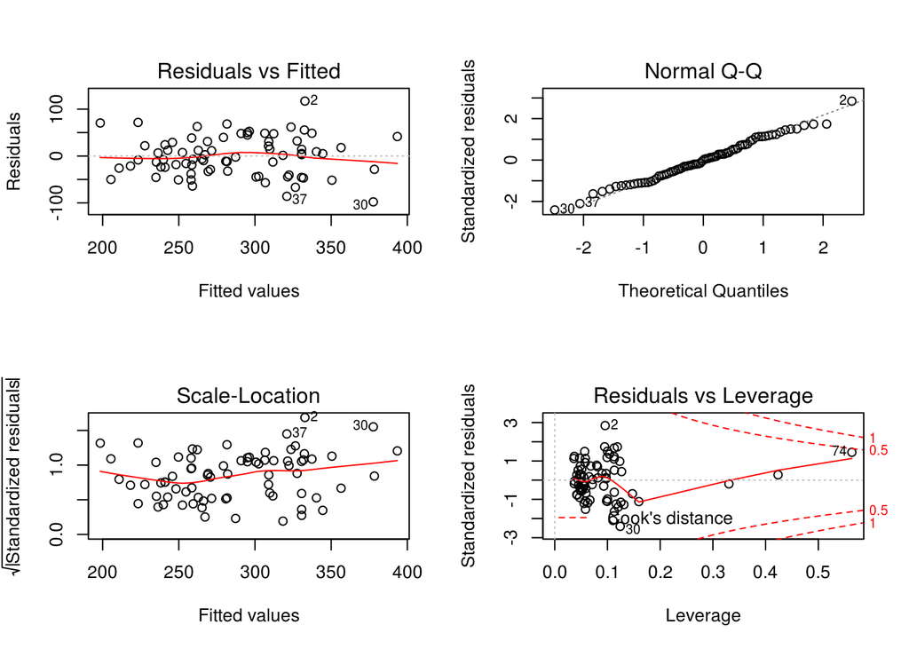

```r
par(mfrow = c(2, 2))
plot(model6)
```

Using the same variables as before, we squared each variable instead of applying log10 to each variable. This significantly increased our model’s overall strength besdies increasing the p-value of the bedrooms by a little bit.

CUBES OF ALL VARIABLES

```r
model7 <- lm(price ~ I((size)^3) + I((lot)^3) + I((bedrooms)^3) + sld + edison + harris, data = housing)
summary(model7)
```

```
##
## Call:
## lm(formula = price ~ I((size)^3) + I((lot)^3) + I((bedrooms)^3) +
##     sld + edison + harris, data = housing)
##
## Residuals:
##     Min      1Q  Median      3Q     Max
## -93.734 -26.466  -0.906  26.102 121.209
##
## Coefficients:
##                  Estimate Std. Error t value Pr(>|t|)
## (Intercept)     239.14662   16.67684  14.340  < 2e-16 ***
## I((size)^3)       5.68269    1.87049   3.038 0.003360 **
## I((lot)^3)        0.12132    0.03121   3.887 0.000230 ***
## I((bedrooms)^3)  -0.29906    0.16019  -1.867 0.066161 .
## sld             -36.87460   10.37230  -3.555 0.000687 ***
## edison           81.25010   14.25022   5.702  2.7e-07 ***
## harris           49.98136   13.51240   3.699 0.000431 ***
## ---
## Signif. codes:  0 '***' 0.001 '**' 0.01 '*' 0.05 '.' 0.1 ' ' 1
##
## Residual standard error: 43.13 on 69 degrees of freedom
## Multiple R-squared:  0.5298, Adjusted R-squared:  0.4889
## F-statistic: 12.96 on 6 and 69 DF,  p-value: 9.438e-10
```

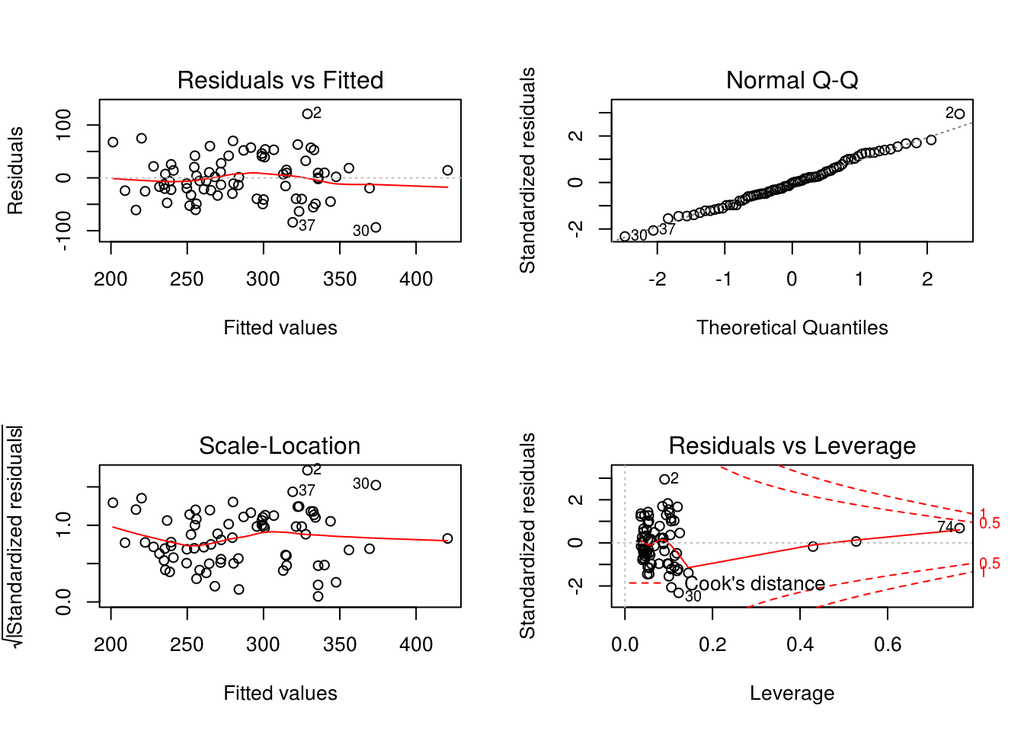

```r
par(mfrow = c(2, 2))
plot(model7)
```

Like before, we took each variable and cubed it to see how it would effect the model. This seems to have had a slightly better impact compared to squaring each variable. The f-statistic and the adjusted R-squared values are slightly higher.

SQUARE ROOTS OF ALL VARIABLES

```r
model8 <- lm(price ~ I((size)^.5) + I((lot)^.5) + I((bedrooms)^.5) + sld + edison + harris, data = housing)
summary(model8)
```

```
##
## Call:
## lm(formula = price ~ I((size)^0.5) + I((lot)^0.5) + I((bedrooms)^0.5) +
##     sld + edison + harris, data = housing)
##
## Residuals:
##     Min      1Q  Median      3Q     Max
## -101.53  -30.60   -1.16   24.64  118.20
##
## Coefficients:
##                   Estimate Std. Error t value Pr(>|t|)
## (Intercept)         -11.55     107.90  -0.107 0.915102
## I((size)^0.5)       254.08      72.89   3.486 0.000858 ***
## I((lot)^0.5)         32.70      13.49   2.425 0.017925 *
## I((bedrooms)^0.5)   -69.01      30.09  -2.293 0.024903 *
## sld                 -35.06      11.04  -3.174 0.002245 **
## edison               79.15      14.92   5.307 1.28e-06 ***
## harris               53.63      15.22   3.523 0.000761 ***
## ---
## Signif. codes:  0 '***' 0.001 '**' 0.01 '*' 0.05 '.' 0.1 ' ' 1
##
## Residual standard error: 45.13 on 69 degrees of freedom
## Multiple R-squared:  0.4853, Adjusted R-squared:  0.4405
## F-statistic: 10.84 on 6 and 69 DF,  p-value: 1.817e-08
```

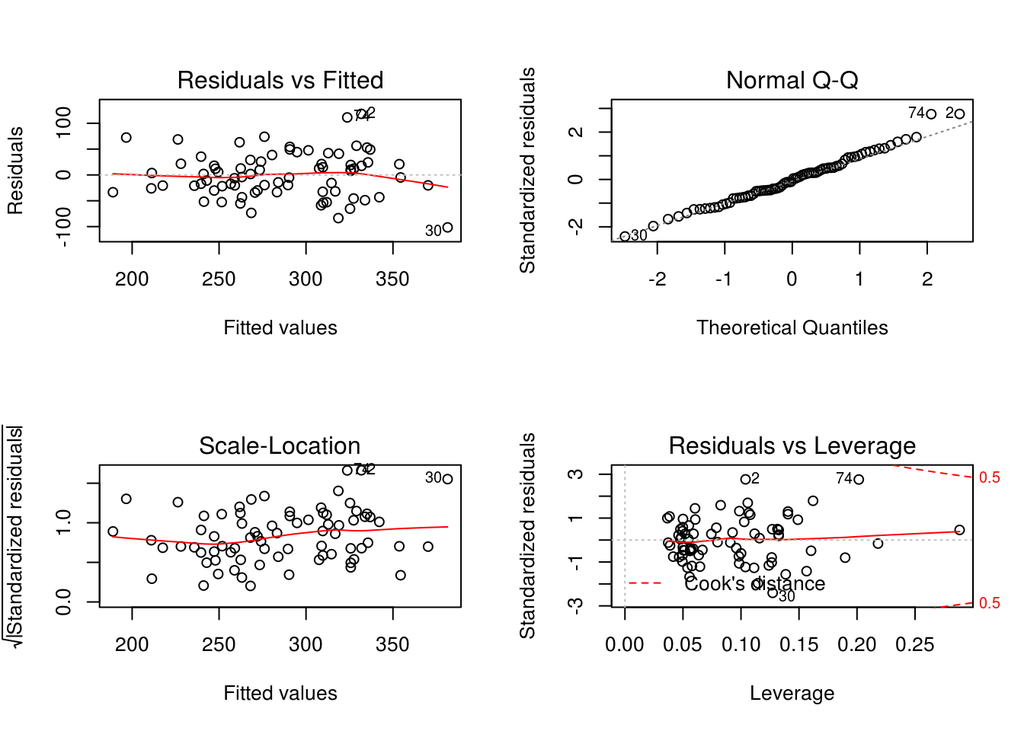

```r
par(mfrow = c(2, 2))
plot(model8)
```

After seeing the strengths of models increasing when the variables are squared and cubed, it isn’t surprising to see the model decrease in strength when the square root is taken of each varibale. Both the f-statistics and the adjusted R-squared value fall below what was found in model3.

A MESS OF INTERACTIVE TERMS

```r
model9 <- lm(price ~ size:lot + size:bedrooms + size:sld + size:edison + size:harris + lot:bedrooms + lot:sld + lot:edison + lot:harris + bedrooms:sld + bedrooms:edison + bedrooms:harris + sld:edison + sld:harris + edison:harris + size + lot + bedrooms + sld + edison + harris, data = housing)
summary(model9)
```

```
##
## Call:
## lm(formula = price ~ size:lot + size:bedrooms + size:sld + size:edison +
##     size:harris + lot:bedrooms + lot:sld + lot:edison + lot:harris +
##     bedrooms:sld + bedrooms:edison + bedrooms:harris + sld:edison +
##     sld:harris + edison:harris + size + lot + bedrooms + sld +
##     edison + harris, data = housing)
##
## Residuals:
##     Min      1Q  Median      3Q     Max
## -87.560 -24.249  -2.077  25.637  73.962
##
## Coefficients: (1 not defined because of singularities)
##                 Estimate Std. Error t value Pr(>|t|)
## (Intercept)      963.258    338.209   2.848  0.00617 **
## size            -281.591    163.276  -1.725  0.09021 .
## lot              -73.832     44.845  -1.646  0.10539
## bedrooms        -142.305     63.523  -2.240  0.02914 *
## sld             -240.097    125.641  -1.911  0.06122 .
## edison          -129.407    150.089  -0.862  0.39232
## harris           -68.283    240.642  -0.284  0.77767
## size:lot          36.157     20.707   1.746  0.08637 .
## size:bedrooms     47.918     27.873   1.719  0.09121 .
## size:sld          26.367     58.729   0.449  0.65522
## size:edison       51.821     81.993   0.632  0.52999
## size:harris      113.678     93.578   1.215  0.22963
## lot:bedrooms       3.626      5.721   0.634  0.52879
## lot:sld            3.309      8.361   0.396  0.69384
## lot:edison        10.273     14.258   0.720  0.47428
## lot:harris       -15.556      9.046  -1.720  0.09111 .
## bedrooms:sld      36.646     18.714   1.958  0.05529 .
## bedrooms:edison    1.154     22.622   0.051  0.95949
## bedrooms:harris  -21.775     48.158  -0.452  0.65293
## sld:edison        81.801     39.571   2.067  0.04343 *
## sld:harris        40.501     39.492   1.026  0.30958
## edison:harris         NA         NA      NA       NA
## ---
## Signif. codes:  0 '***' 0.001 '**' 0.01 '*' 0.05 '.' 0.1 ' ' 1
##
## Residual standard error: 41.65 on 55 degrees of freedom
## Multiple R-squared:  0.6506, Adjusted R-squared:  0.5235
## F-statistic:  5.12 on 20 and 55 DF,  p-value: 7.497e-07
```

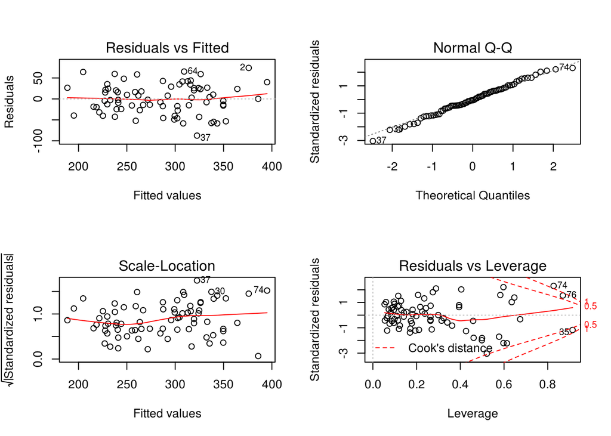

```r
par(mfrow = c(2, 2))
plot(model9)
```

This model displays numerous variable interactions. It is interesting to see that the adjusted R-squared is one of the highest we have had so far. A drawback is that the f-statistic is lower than most we have seen.

REMOVED TERMS ONE BY ONE

```r
model10 <- lm(price ~ size:lot + size:harris + lot:harris + sld:edison + sld, data = housing)
summary(model10)
```

```
##
## Call:
## lm(formula = price ~ size:lot + size:harris + lot:harris + sld:edison +
##     sld, data = housing)
##
## Residuals:
##      Min       1Q   Median       3Q      Max
## -107.333  -28.536   -3.955   31.300   91.804
##
## Coefficients:
##             Estimate Std. Error t value Pr(>|t|)
## (Intercept)  211.640     15.078  14.036  < 2e-16 ***
## sld          -46.690     10.102  -4.622 1.69e-05 ***
## size:lot       9.277      1.536   6.040 6.65e-08 ***
## size:harris   71.013     11.875   5.980 8.50e-08 ***
## lot:harris   -23.734      6.201  -3.828 0.000278 ***
## sld:edison    97.973     15.751   6.220 3.19e-08 ***
## ---
## Signif. codes:  0 '***' 0.001 '**' 0.01 '*' 0.05 '.' 0.1 ' ' 1
##
## Residual standard error: 40.79 on 70 degrees of freedom
## Multiple R-squared:  0.5734, Adjusted R-squared:  0.5429
## F-statistic: 18.82 on 5 and 70 DF,  p-value: 8.278e-12
```

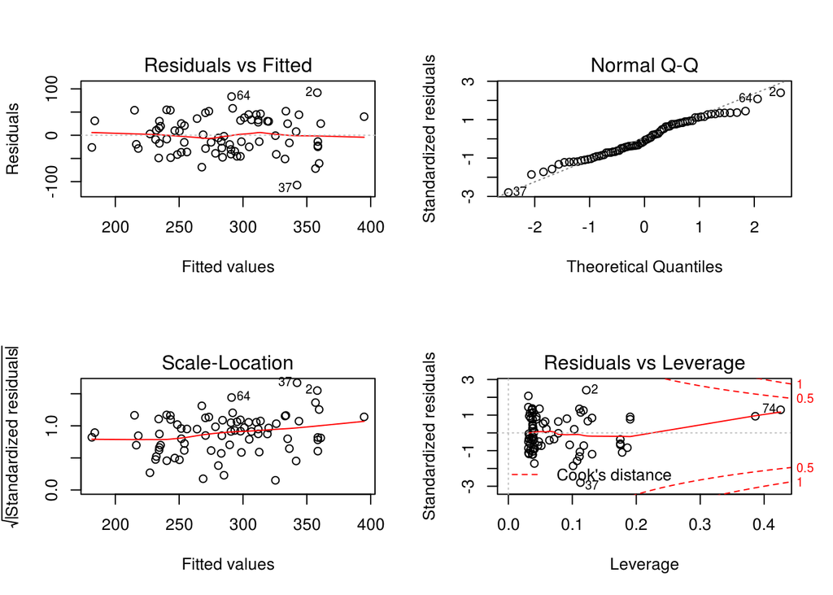

```r
par(mfrow = c(2, 2))
plot(model10)
```

## 4) Model Modification

- Consider modifying your model based upon your initial results and/or diagnostic plots from the model. Explain any modifications that you are making. Consider variance inflation factors for each predictor in your model and comment on that in your model selection process.

By looking at the diagnostic plots for model 10, it is apparent that there are two points are high leverage. We should first take these out to see how they change our model.

```r
housing2 <- housing[c(-74, -66),]
model.f <- lm(price ~ size:lot + size:harris + lot:harris + sld:edison + sld, data = housing2)
summary(model.f)
```

```
##
## Call:
## lm(formula = price ~ size:lot + size:harris + lot:harris + sld:edison +
##     sld, data = housing2)
##
## Residuals:
##      Min       1Q   Median       3Q      Max
## -105.496  -28.879   -6.856   30.533   96.647
##
## Coefficients:
##             Estimate Std. Error t value Pr(>|t|)
## (Intercept)  226.155     18.410  12.284  < 2e-16 ***
## sld          -48.747     10.358  -4.706 1.28e-05 ***
## size:lot       7.519      1.983   3.791 0.000321 ***
## size:harris   68.442     13.106   5.222 1.83e-06 ***
## lot:harris   -24.455      7.524  -3.250 0.001795 **
## sld:edison    98.730     15.733   6.275 2.79e-08 ***
## ---
## Signif. codes:  0 '***' 0.001 '**' 0.01 '*' 0.05 '.' 0.1 ' ' 1
##
## Residual standard error: 40.6 on 68 degrees of freedom
## Multiple R-squared:  0.5443, Adjusted R-squared:  0.5108
## F-statistic: 16.24 on 5 and 68 DF,  p-value: 1.626e-10
```

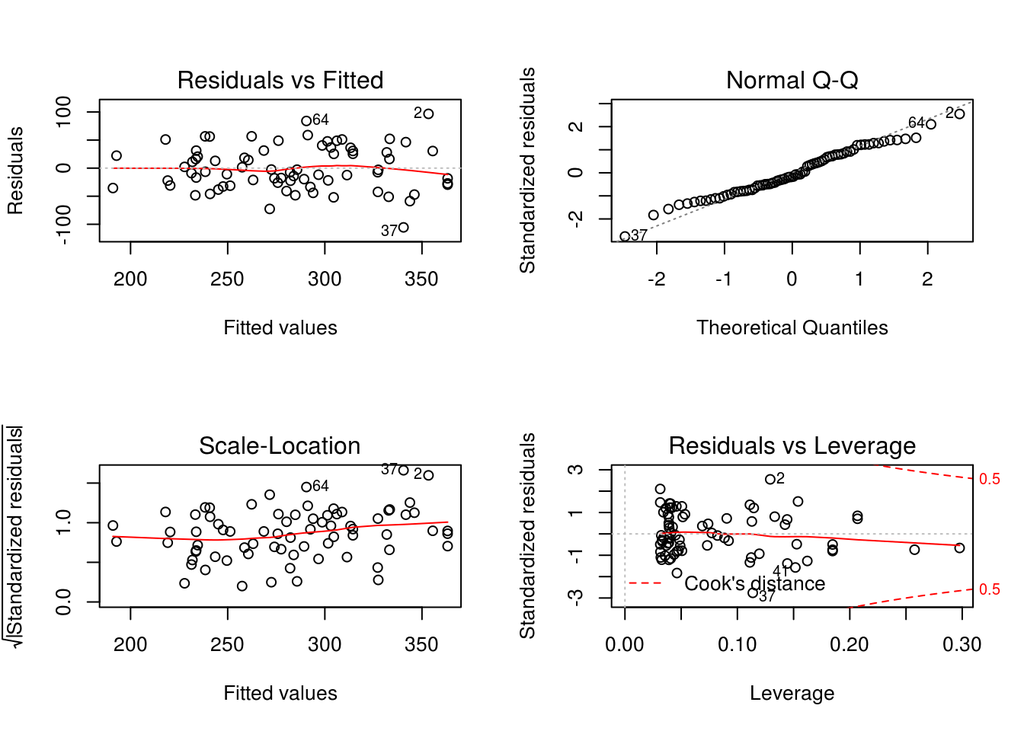

```r
par(mfrow = c(2, 2))
plot(model.f)
```

This gives us a slightly smaller f-statistic and adjusted R-squared value. Regardless, both are very similar. we can write this version of the model as
$$price = 226.155-48.747(sld)+7.519(size:lot)+68.442(size:harris)-24.455(lot:harris)+98.730(sld:edison)$$

```r
library(car)
vif(model.f)
```

```
##         sld    size:lot size:harris  lot:harris  sld:edison
##    1.203889    1.480608    4.435682    3.724436    1.186950
```

Calculating the VIF helps determine to see how well each predictor is associated with the other predictors in the model. Looking at the values given, there is nothing to suggest that this model is over-fitting in any way. The interactive term `size:harris` is the largest, but it isn’t too concerning at its current value.

## 5) Conclusion

```r
confint(model.f)
```

```
##                  2.5 %     97.5 %
## (Intercept) 189.418745 262.892124
## sld         -69.415644 -28.079269
## size:lot      3.561311  11.475748
## size:harris  42.289536  94.594095
## lot:harris  -39.470175  -9.440641
## sld:edison   67.335535 130.123882
```

```r
predict(model.f, newdata = data.frame(size = 1, lot = 1, harris = 1, sld = 1, edison = 0), interval = "confidence")
```

```
##        fit      lwr      upr
## 1 228.9129 203.4061 254.4197
```

Our final model for predicting the price of a house based off the data provided can be expressed as
$$price = 226.155-48.747(sld)+7.519(size:lot)+68.442(size:harris)-24.455(lot:harris)+98.730(sld:edison)$$
. This model is similar to that of model10, but it lacks two points with high leverage. This model gives us an adjusted R-squared value of $0.5108$. The 95% confidence intervals for each variable :

- intercept - [189.418745, 262.892124]
- sld - [-69.415644, -28.079269]
- size:lot - [3.561311, 11.475748]
- size:harris - [42.289536, 94.594095]
- lot:harris - [-39.470175, -9.440641]
- sld:edison - [67.335535, 130.123882]